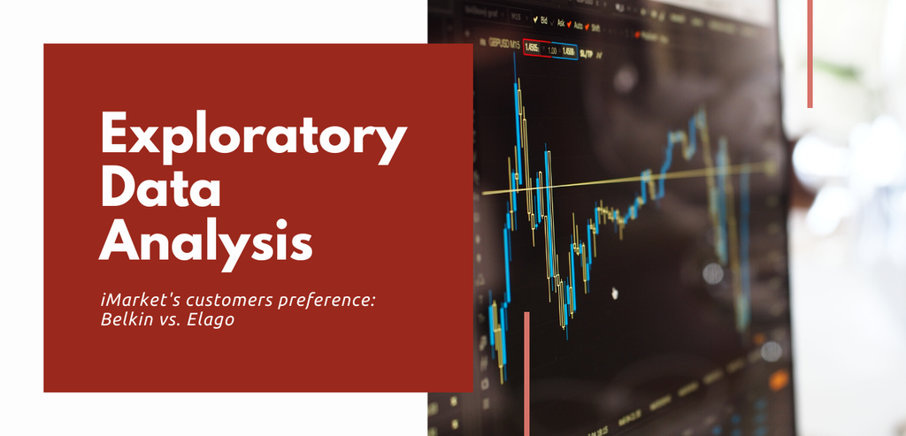

This documents aims to give a general view towards the brand preference within iMarket’s customers.

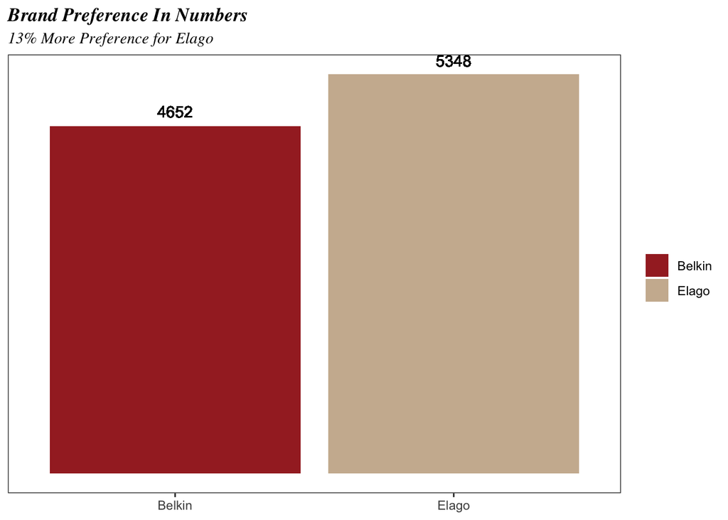

The plot above shows us that there is a slightly bigger preference for Elago. The following graph gives us a clearer sight concerning which is the profile of those who prefer Elago:

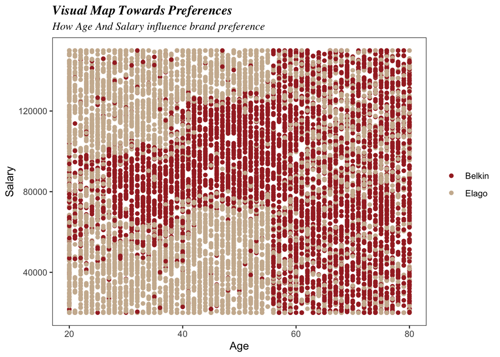

[figure not shown]

We found no relevant correlation between brand preference and region, educational level and car owned. Age and salary can slightly influence the customer’s preference. It is also important to mention that customers who refused to answer their brand preference were not taken into consideration. For better undertanding, we could build a predictive model that would predict the no responser’s choice.